# Data Science Course Project

Problem Statement: To predict if a person have heart disease or not based on attributes blood pressure,heart beat , exang = (exang: Exercise induced angina (1 = yes; 0 = no) ) fbs = (Fasting blood sugar (FBS) measures blood glucose after you have not eaten for at least 8 hours) (1 if blood sugar>120 mg) cp = chest pain (0<1<2<3) ca = coronary calcium scan trestbps = resting blood pressure in mmHg chol = cholesterol (mg) thalach = maximum heart rate oldpeak = ST(points on ECG plot) depression induced by exercise relative to rest restecg = rest Electro cardio graph target = if there is heart disease it will show 1 otherwise it will show 0

```r
install.packages("tidyverse")
library(tidyverse)
data<-read.csv("C:/Users/shubh/Downloads/heart.csv")
View(data)
```

```r
head(data)
```

|  | age | sex | cp | trestbps | chol | fbs | restecg | thalach | exang | oldpeak | slope | ca | thal | target |
| --- | --- | --- | --- | --- | --- | --- | --- | --- | --- | --- | --- | --- | --- | --- |
| 1 | 52 | 1 | 0 | 125 | 212 | 0 | 1 | 168 | 0 | 1.0 | 2 | 2 | 3 | 0 |
| 2 | 53 | 1 | 0 | 140 | 203 | 1 | 0 | 155 | 1 | 3.1 | 0 | 0 | 3 | 0 |
| 3 | 70 | 1 | 0 | 145 | 174 | 0 | 1 | 125 | 1 | 2.6 | 0 | 0 | 3 | 0 |
| 4 | 61 | 1 | 0 | 148 | 203 | 0 | 1 | 161 | 0 | 0.0 | 2 | 1 | 3 | 0 |
| 5 | 62 | 0 | 0 | 138 | 294 | 1 | 1 | 106 | 0 | 1.9 | 1 | 3 | 2 | 0 |
| 6 | 58 | 0 | 0 | 100 | 248 | 0 | 0 | 122 | 0 | 1.0 | 1 | 0 | 2 | 1 |

```r
tail(data)
```

|  | age | sex | cp | trestbps | chol | fbs | restecg | thalach | exang | oldpeak | slope | ca | thal | target |
| --- | --- | --- | --- | --- | --- | --- | --- | --- | --- | --- | --- | --- | --- | --- |
| 1020 | 47 | 1 | 0 | 112 | 204 | 0 | 1 | 143 | 0 | 0.1 | 2 | 0 | 2 | 1 |
| 1021 | 59 | 1 | 1 | 140 | 221 | 0 | 1 | 164 | 1 | 0.0 | 2 | 0 | 2 | 1 |
| 1022 | 60 | 1 | 0 | 125 | 258 | 0 | 0 | 141 | 1 | 2.8 | 1 | 1 | 3 | 0 |
| 1023 | 47 | 1 | 0 | 110 | 275 | 0 | 0 | 118 | 1 | 1.0 | 1 | 1 | 2 | 0 |
| 1024 | 50 | 0 | 0 | 110 | 254 | 0 | 0 | 159 | 0 | 0.0 | 2 | 0 | 2 | 1 |
| 1025 | 54 | 1 | 0 | 120 | 188 | 0 | 1 | 113 | 0 | 1.4 | 1 | 1 | 3 | 0 |

```r
glimpse(data)
```

```
Rows: 1,025
Columns: 14
$ age      <int> 52, 53, 70, 61, 62, 58, 58, 55, 46, 54, 71, 43, 34, 51, 52, 34…
$ sex      <int> 1, 1, 1, 1, 0, 0, 1, 1, 1, 1, 0, 0, 0, 1, 1, 0, 0, 1, 0, 1, 1,…
$ cp       <int> 0, 0, 0, 0, 0, 0, 0, 0, 0, 0, 0, 0, 1, 0, 0, 1, 2, 0, 1, 2, 2,…
$ trestbps <int> 125, 140, 145, 148, 138, 100, 114, 160, 120, 122, 112, 132, 11…
$ chol     <int> 212, 203, 174, 203, 294, 248, 318, 289, 249, 286, 149, 341, 21…
$ fbs      <int> 0, 1, 0, 0, 1, 0, 0, 0, 0, 0, 0, 1, 0, 0, 1, 0, 0, 0, 0, 1, 0,…
$ restecg  <int> 1, 0, 1, 1, 1, 0, 2, 0, 0, 0, 1, 0, 1, 1, 1, 1, 0, 0, 1, 0, 0,…
$ thalach  <int> 168, 155, 125, 161, 106, 122, 140, 145, 144, 116, 125, 136, 19…
$ exang    <int> 0, 1, 1, 0, 0, 0, 0, 1, 0, 1, 0, 1, 0, 1, 1, 0, 0, 1, 0, 0, 0,…
$ oldpeak  <dbl> 1.0, 3.1, 2.6, 0.0, 1.9, 1.0, 4.4, 0.8, 0.8, 3.2, 1.6, 3.0, 0.…
$ slope    <int> 2, 0, 0, 2, 1, 1, 0, 1, 2, 1, 1, 1, 2, 1, 1, 2, 2, 1, 2, 2, 1,…
$ ca       <int> 2, 0, 0, 1, 3, 0, 3, 1, 0, 2, 0, 0, 0, 3, 0, 0, 1, 1, 0, 0, 0,…
$ thal     <int> 3, 3, 3, 3, 2, 2, 1, 3, 3, 2, 2, 3, 2, 3, 0, 2, 2, 3, 2, 2, 2,…
$ target   <int> 0, 0, 0, 0, 0, 1, 0, 0, 0, 0, 1, 0, 1, 0, 0, 1, 1, 0, 1, 1, 0,…
```

```r
ncol(data)
```

```
[1] 14
```

```r
nrow(data)
```

```
[1] 1025
```

```r
summary(data)
```

```
      age             sex               cp            trestbps          chol
 Min.   :29.00   Min.   :0.0000   Min.   :0.0000   Min.   : 94.0   Min.   :126
 1st Qu.:48.00   1st Qu.:0.0000   1st Qu.:0.0000   1st Qu.:120.0   1st Qu.:211
 Median :56.00   Median :1.0000   Median :1.0000   Median :130.0   Median :240
 Mean   :54.43   Mean   :0.6956   Mean   :0.9424   Mean   :131.6   Mean   :246
 3rd Qu.:61.00   3rd Qu.:1.0000   3rd Qu.:2.0000   3rd Qu.:140.0   3rd Qu.:275
 Max.   :77.00   Max.   :1.0000   Max.   :3.0000   Max.   :200.0   Max.   :564
      fbs            restecg          thalach          exang
 Min.   :0.0000   Min.   :0.0000   Min.   : 71.0   Min.   :0.0000
 1st Qu.:0.0000   1st Qu.:0.0000   1st Qu.:132.0   1st Qu.:0.0000
 Median :0.0000   Median :1.0000   Median :152.0   Median :0.0000
 Mean   :0.1493   Mean   :0.5298   Mean   :149.1   Mean   :0.3366
 3rd Qu.:0.0000   3rd Qu.:1.0000   3rd Qu.:166.0   3rd Qu.:1.0000
 Max.   :1.0000   Max.   :2.0000   Max.   :202.0   Max.   :1.0000
    oldpeak          slope             ca              thal
 Min.   :0.000   Min.   :0.000   Min.   :0.0000   Min.   :0.000
 1st Qu.:0.000   1st Qu.:1.000   1st Qu.:0.0000   1st Qu.:2.000
 Median :0.800   Median :1.000   Median :0.0000   Median :2.000
 Mean   :1.072   Mean   :1.385   Mean   :0.7541   Mean   :2.324
 3rd Qu.:1.800   3rd Qu.:2.000   3rd Qu.:1.0000   3rd Qu.:3.000
 Max.   :6.200   Max.   :2.000   Max.   :4.0000   Max.   :3.000
     target
 Min.   :0.0000
 1st Qu.:0.0000
 Median :1.0000
 Mean   :0.5132
 3rd Qu.:1.0000
 Max.   :1.0000
```

```r
data2<- data %>%
  mutate(sex=if_else(sex==1,"male","female"),
         fbs=if_else(fbs==1,">120","<=120"),
         exang=if_else(exang==1,"yes","no"),
         cp=if_else(cp==1,"ATYPICAL ANGINA",
                    if_else(cp==2,"NON-ANGINAL PAIN","ASYMPTOMATIC")),
         restecg=if_else(restecg==0,"NORMAL",
         if_else(restecg==1,"ABNORMALITY","PROBABLE OR DEFINITIVE")),
         slope=as.factor(slope),
         ca=as.factor(ca),
         thal=as.factor(thal),
         target=if_else(target==1 ,"YES","NO")
         ) %>%
  mutate_if(is.character,as.factor) %>%
  dplyr::select(target,sex,fbs,exang,cp,restecg,slope,ca,thal,everything())
  #install.packages("repr")
  library(repr)
```

```r
# change the size of the plot
options(repr.plot.width =6 ,repr.plot.height = 3)
```

```r
#bar plot for target (heart disease)
ggplot(data2,aes(x=data2$target,fill=data2$target))+
  geom_bar() +
  xlab("Heart Disease") +
  ylab("Count") +
  ggtitle("Presence & Absence of Heart Disease") +
  scale_fill_discrete(name = 'Heart Disease', labels = c("Absent", "Present"))
```

```
Error in ggplot(data2, aes(x = data2$target, fill = data2$target)) :
  could not find function "ggplot"
```

```r
prop.table(table(data2$target))
```

```
       NO       YES
0.4868293 0.5131707
```

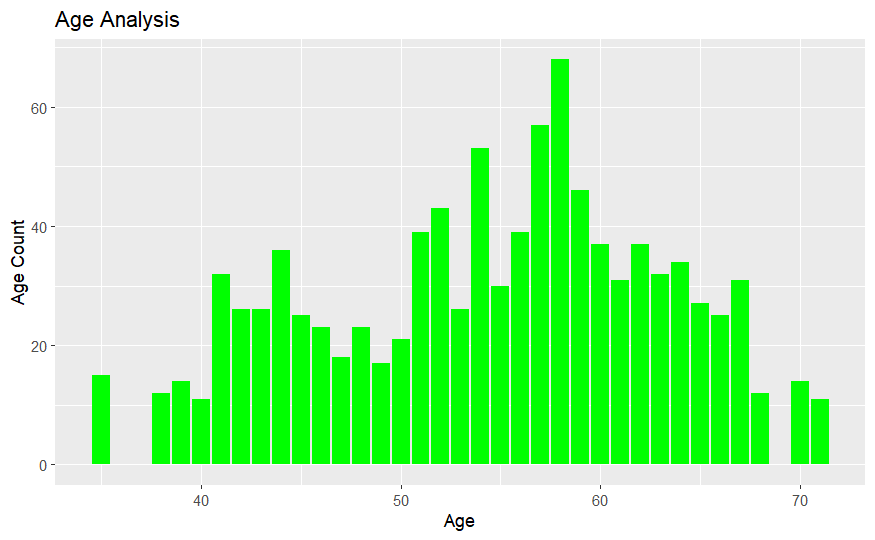

```r
#count the frequency of the values of age

data2 %>%
  group_by(age) %>%
  count() %>%
  filter(n>10) %>%
  ggplot()+
  geom_col(aes(age,n),fill='green')+
  ggtitle("Age Analysis")+
  xlab("Age")+
  ylab("Age Count")
```

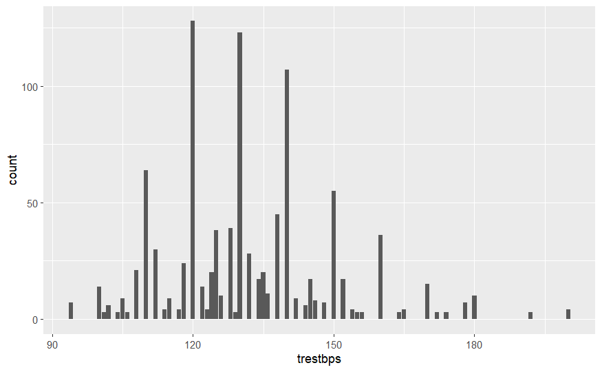

```r
#plot the distribution of the resting blood pressure
ggplot(data2,aes(x=trestbps))+
  geom_bar()
```

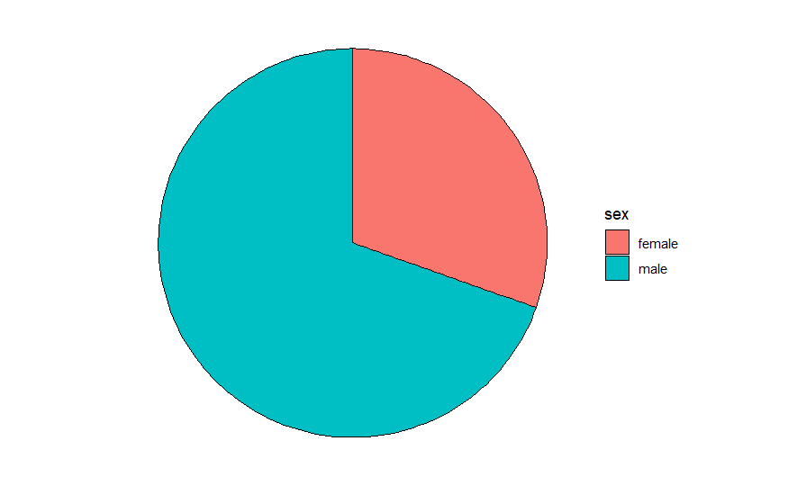

```r
#create a basic ggplot2 pie chart displaying the sex column of thne dataset
plotdata<- data2 %>%
  count(sex) %>%
  arrange(desc(sex)) %>%
  mutate(prop = round(n*100/sum(n),1),
         lab.ypos=cumsum(prop)- 0.5 *prop)
ggplot(plotdata,
       aes(x=" ",
           y=prop,
           fill=sex))+
  geom_bar(width=1,
           stat = "identity",
           color="black")+
  coord_polar("y",
              start =0,
              direction = -1)+
  theme_void()
```

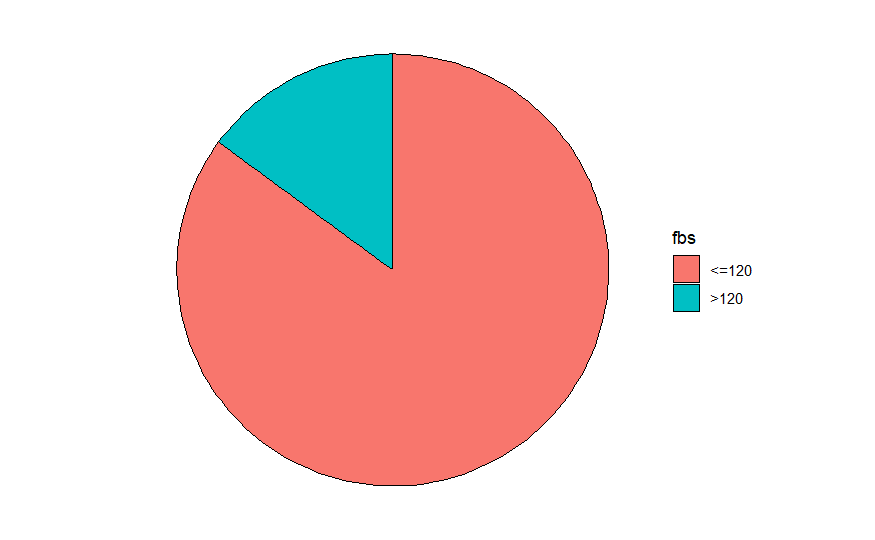

```r
#fasting blood sugar
plotdata<- data2 %>%
  count(fbs) %>%
  arrange(desc(fbs)) %>%
  mutate(prop=round(n*100/sum(n), 1),
         lab.ypos=cumsum(prop)- 0.5 * prop)
 ggplot(plotdata,
        aes(x=" ",
            y=prop,
            fill=fbs))+
   geom_bar(width=1,
            stat = "identity",
            color="black")+
   coord_polar("y",
               start = 0,
               direction = -1)+
   theme_void()
```

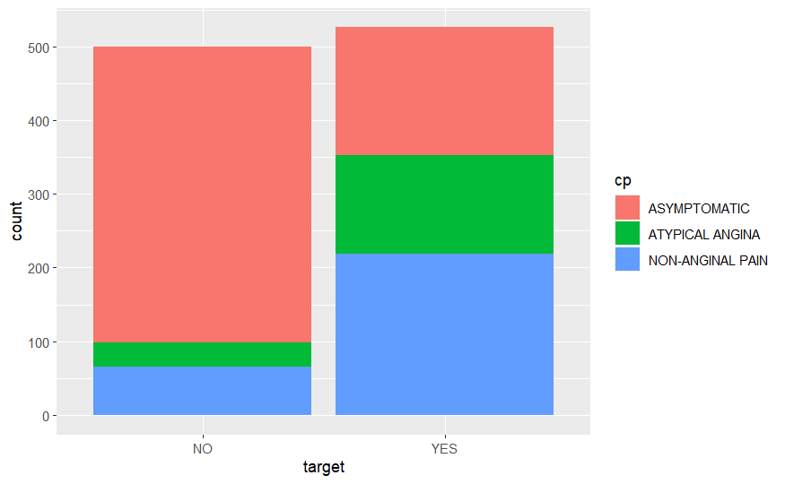

```r
#bivariate plots dependent on two variables for displaying the result

#cp: the chest pain experienced (value 1: typical angina, value 2: atypical angina , value 3: non anginal pain , value 4: asymptomatic)
ggplot(data2,
       aes(x=target,
           fill=cp ))+
  geom_bar(position = "stack")
```

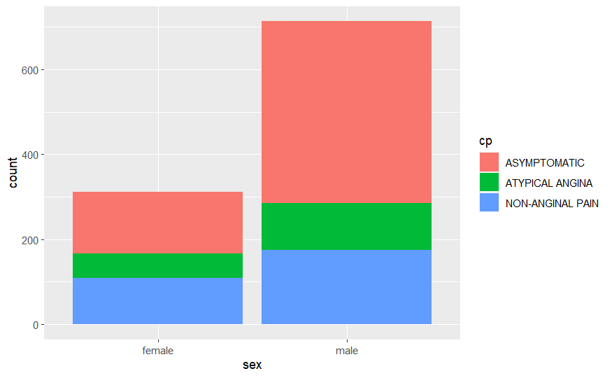

```r
ggplot(data2,
       aes(x=sex,
           fill=cp))+
  geom_bar(position = "stack")
```

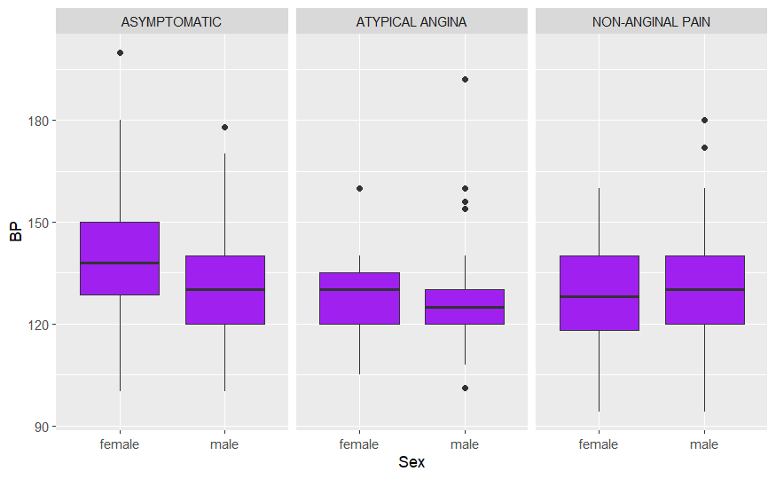

```r
#compare blood pressure across the chest pain by their respective genders

data2 %>%
  ggplot(aes(x=sex,y=trestbps))+
  geom_boxplot(fill='purple')+
  xlab("Sex")+
  ylab("BP")+
  facet_grid(~cp)
```

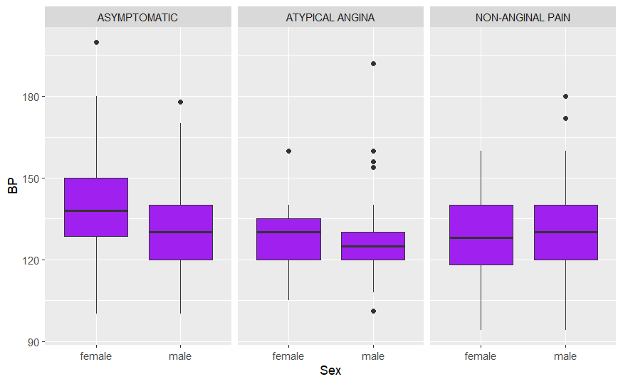

```r
#compare blood pressure across the chest pain irrespective of their genders
data2 %>%
  ggplot(aes(x=sex,y=trestbps))+
  geom_boxplot(fill="purple")+
  xlab("Sex")+
  ylab("BP")+
  facet_grid(~cp)
```

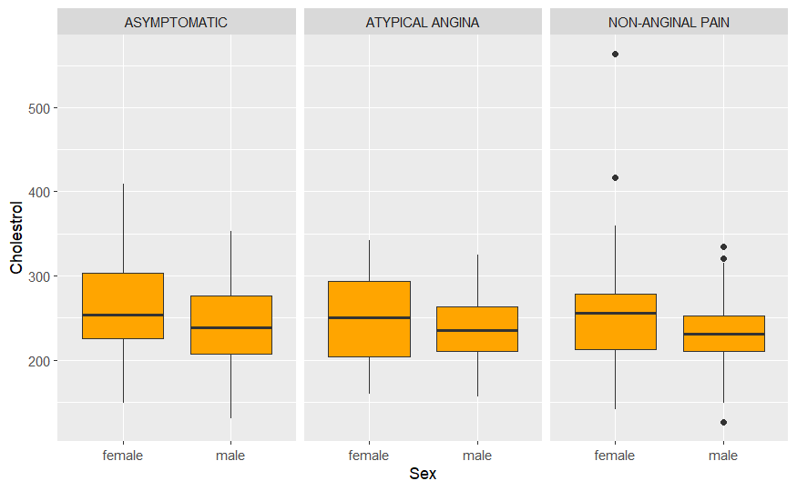

```r
#compare cholestrol across the chest pain by their respective genders
data2 %>%
  ggplot(aes(x=sex,y=chol))+
  geom_boxplot(fill="orange")+
  xlab("Sex")+
  ylab("Cholestrol")+
  facet_grid(~cp)
```

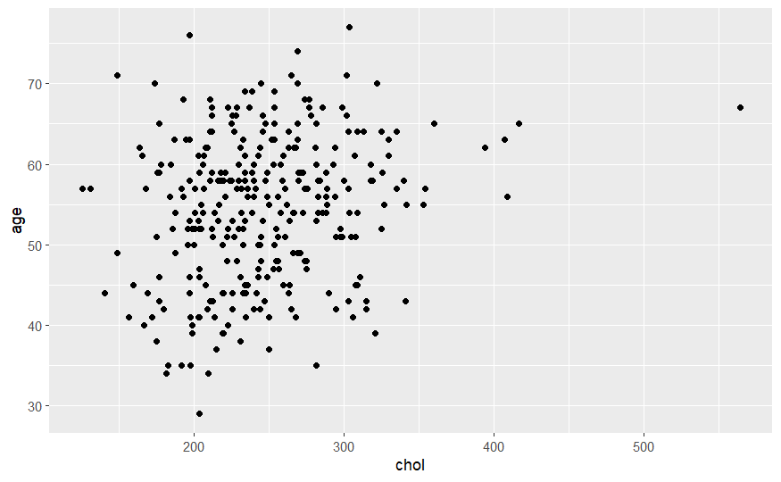

```r
#simple scatterplot
ggplot(data2,
       aes(x=chol,
           y=age))+
  geom_point()
```

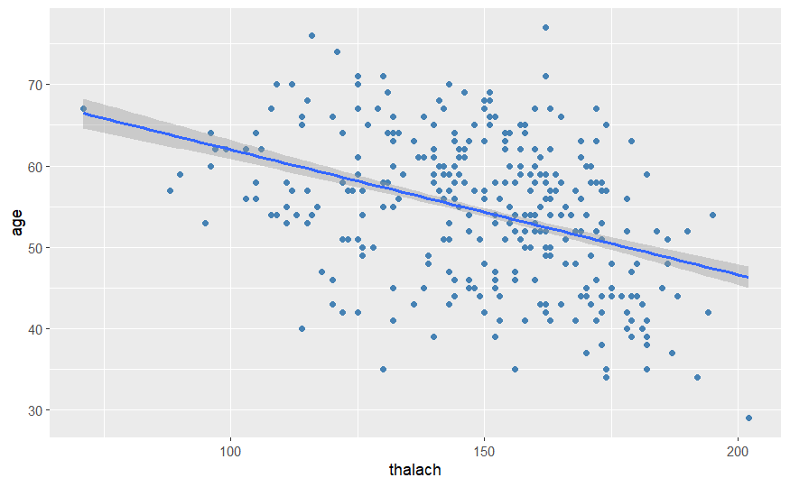

```r
#scatterplot with a linear progression direction
#thalach : maximum heart rate achieved
ggplot(data2,
       aes(x=thalach,
           y=age))+
  geom_point(color="steelblue")+
  geom_smooth(method = "lm")
```

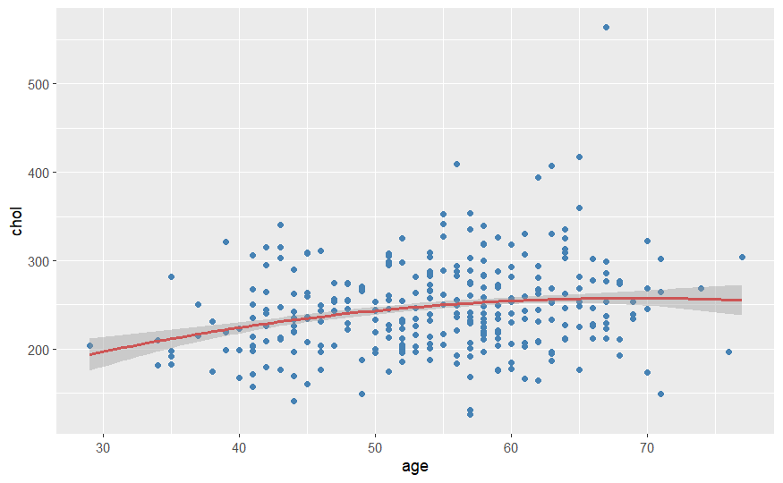

```r
#Scatterplot with a polynomial direction , comparing age with cholestrol
ggplot(data2,
       aes(x=age,
           y=chol))+
  geom_point(color="steelblue")+
  geom_smooth(method = "lm",
              formula = y~poly(x,2),
              color="indianred3")
```

```r
install.packages('caTools')
```

```
Error in install.packages : Updating loaded packages
```

```r
library(caTools)

#randomly split data
set.seed(123)
split=sample.split(data$target,SplitRatio = 0.75)
split
```

```
   [1]  TRUE FALSE  TRUE FALSE FALSE FALSE  TRUE  TRUE FALSE  TRUE  TRUE  TRUE
  [13]  TRUE FALSE  TRUE  TRUE  TRUE  TRUE  TRUE  TRUE  TRUE  TRUE  TRUE FALSE
  [25]  TRUE  TRUE  TRUE FALSE  TRUE  TRUE  TRUE  TRUE FALSE FALSE FALSE  TRUE
  [37]  TRUE  TRUE  TRUE  TRUE  TRUE FALSE FALSE  TRUE  TRUE FALSE  TRUE  TRUE
  [49]  TRUE  TRUE  TRUE  TRUE  TRUE  TRUE  TRUE FALSE  TRUE  TRUE FALSE  TRUE
  [61] FALSE  TRUE FALSE FALSE  TRUE  TRUE FALSE  TRUE  TRUE FALSE  TRUE  TRUE
  [73]  TRUE  TRUE  TRUE  TRUE FALSE  TRUE  TRUE  TRUE  TRUE  TRUE  TRUE  TRUE
  [85] FALSE  TRUE  TRUE  TRUE  TRUE  TRUE FALSE  TRUE FALSE  TRUE FALSE  TRUE
  [97]  TRUE  TRUE FALSE FALSE  TRUE FALSE FALSE  TRUE  TRUE  TRUE  TRUE  TRUE
 [109]  TRUE FALSE FALSE  TRUE  TRUE  TRUE  TRUE  TRUE  TRUE FALSE  TRUE FALSE
 [121]  TRUE  TRUE FALSE  TRUE FALSE  TRUE  TRUE  TRUE  TRUE  TRUE FALSE FALSE
 [133]  TRUE  TRUE  TRUE FALSE  TRUE FALSE  TRUE FALSE  TRUE FALSE  TRUE  TRUE
 [145] FALSE  TRUE  TRUE  TRUE  TRUE FALSE  TRUE  TRUE  TRUE  TRUE  TRUE  TRUE
 [157]  TRUE  TRUE  TRUE FALSE  TRUE FALSE  TRUE  TRUE  TRUE  TRUE FALSE FALSE
 [169]  TRUE FALSE  TRUE  TRUE  TRUE  TRUE  TRUE FALSE FALSE FALSE  TRUE  TRUE
```

[output cut: 70 more lines]

```r
qualityTrain=subset(data,split==TRUE)
qualityTest=subset(data,split==FALSE)
```

```r
nrow(qualityTrain)
```

```
[1] 768
```

```r
nrow(qualityTest)
```

```
[1] 257
```

```r
#building the model
# the dependent variable used is target, for the independent variable is age , trestbps, chol, fbs , restecg, thalach,exang, oldpeak,slope
#e,ca,and thal.
#logistic regression model
data=glm(target ~
           age+trestbps+chol+fbs+
           restecg+thalach+exang+oldpeak+slope+ca+thal,
         data = qualityTrain,family = binomial)
summary(data)
```

```
Call:
glm(formula = target ~ age + trestbps + chol + fbs + restecg +
    thalach + exang + oldpeak + slope + ca + thal, family = binomial,
    data = qualityTrain)

Coefficients:
             Estimate Std. Error z value Pr(>|z|)
(Intercept)  0.920225   1.375892   0.669   0.5036
age          0.009849   0.012868   0.765   0.4441
trestbps    -0.011993   0.006111  -1.962   0.0497 *
chol        -0.001980   0.001998  -0.991   0.3217
fbs         -0.110037   0.284366  -0.387   0.6988
restecg      0.429773   0.193682   2.219   0.0265 *
thalach      0.026912   0.005447   4.941 7.78e-07 ***
exang       -1.432701   0.226152  -6.335 2.37e-10 ***
oldpeak     -0.534307   0.122504  -4.362 1.29e-05 ***
slope        0.264212   0.203104   1.301   0.1933
ca          -0.744475   0.105260  -7.073 1.52e-12 ***
thal        -1.066529   0.164099  -6.499 8.07e-11 ***
---
Signif. codes:  0 ‘***’ 0.001 ‘**’ 0.01 ‘*’ 0.05 ‘.’ 0.1 ‘ ’ 1

(Dispersion parameter for binomial family taken to be 1)

    Null deviance: 1064.15  on 767  degrees of freedom
Residual deviance:  648.45  on 756  degrees of freedom
AIC: 672.45

Number of Fisher Scoring iterations: 5
```

```r
#a lot of variables are not significant.
#now we will removing variables based on Significance level
#using the backward method

data=glm(target~age+sex+cp+trestbps+chol+fbs+thalach+
           exang+oldpeak+slope+ca+thal,
         data=qualityTrain,family = binomial)
summary(data)
```

```
Call:
glm(formula = target ~ age + sex + cp + trestbps + chol + fbs +
    thalach + exang + oldpeak + slope + ca + thal, family = binomial,
    data = qualityTrain)

Coefficients:
             Estimate Std. Error z value Pr(>|z|)
(Intercept)  4.346428   1.594924   2.725 0.006427 **
age         -0.009787   0.014447  -0.677 0.498144
sex         -1.819584   0.292848  -6.213 5.18e-10 ***
cp           0.826071   0.114158   7.236 4.61e-13 ***
trestbps    -0.021123   0.006696  -3.155 0.001607 **
chol        -0.005885   0.002308  -2.549 0.010789 *
fbs         -0.437189   0.330000  -1.325 0.185233
thalach      0.025744   0.006451   3.991 6.59e-05 ***
exang       -0.994883   0.260534  -3.819 0.000134 ***
oldpeak     -0.570869   0.133733  -4.269 1.97e-05 ***
slope        0.403103   0.219380   1.837 0.066141 .
ca          -0.731254   0.117394  -6.229 4.69e-10 ***
thal        -0.907643   0.176779  -5.134 2.83e-07 ***
---
Signif. codes:  0 ‘***’ 0.001 ‘**’ 0.01 ‘*’ 0.05 ‘.’ 0.1 ‘ ’ 1

(Dispersion parameter for binomial family taken to be 1)

    Null deviance: 1064.15  on 767  degrees of freedom
Residual deviance:  552.85  on 755  degrees of freedom
AIC: 578.85

Number of Fisher Scoring iterations: 6
```

```r
#after removing as many as 4 variables in the following order :
#1.remove restecg
#2.remove fbs
#3.remove slope
#4.remove exang

data=glm(target~sex+cp+trestbps+chol+thalach+oldpeak+ca+thal,
         data=qualityTrain,family = binomial)
summary(data)
```

```
Call:
glm(formula = target ~ sex + cp + trestbps + chol + thalach +
    oldpeak + ca + thal, family = binomial, data = qualityTrain)

Coefficients:
             Estimate Std. Error z value Pr(>|z|)
(Intercept)  3.227150   1.236447   2.610  0.00905 **
sex         -1.775648   0.273049  -6.503 7.87e-11 ***
cp           0.903478   0.106178   8.509  < 2e-16 ***
trestbps    -0.024433   0.006385  -3.827  0.00013 ***
chol        -0.006261   0.002167  -2.889  0.00387 **
thalach      0.034233   0.005690   6.017 1.78e-09 ***
oldpeak     -0.761385   0.116591  -6.530 6.56e-11 ***
ca          -0.699798   0.111297  -6.288 3.22e-10 ***
thal        -0.864291   0.172030  -5.024 5.06e-07 ***
---
Signif. codes:  0 ‘***’ 0.001 ‘**’ 0.01 ‘*’ 0.05 ‘.’ 0.1 ‘ ’ 1

(Dispersion parameter for binomial family taken to be 1)

    Null deviance: 1064.15  on 767  degrees of freedom
Residual deviance:  575.86  on 759  degrees of freedom
AIC: 593.86

Number of Fisher Scoring iterations: 6
```